# Multiple testing

DSCI 632: Statistics for Data Science

Peter Ralph

# Multiple comparisons

## A silly example

Suppose 100 people did 100 well-executed experiments to ask if snails move faster while listening to metal than to mozart.

How many would find a statistically significant difference at $p < 0.05$?

Would any find a large effect?

## A less silly example

Suppose someone conducts a well-controlled study that records cancer incidence and the mean daily consumption of 100 different foods in a bunch of people.

How many of the foods would be statistically significantly associated with lower infection rates at $p < 0.05$?

Would any have a large effect?

## The problem

A $p$-value is

> the probability of seeing something at least as extreme as what was seen in the data, if the null hypothesis were true.

So, if the null hypothesis *is* true, then **by definition**, $p$-values are uniformly distributed between 0 and 1,

and so $\P\{ p < 0.05 \} = 0.05$.

*Note:* if the null hypothesis is *not* true, then what happens depends on the statistical power and the size of the effect.

## Another silly example

Suppose 100 people did 100 well-executed experiments to ask if dogs are more likely to wag their tails when they see their owners than cats.

How many would find a statistically significant difference at $p < 0.05$?

Would any find a large effect?

## Another less silly example

Suppose someone conducts 100 well-controlled Phase II clinical studies that each record disease severity for a different drug that showed promise in earlier studies.

How many of the drugs would be statistically significantly associated with reduced disease severity at $p < 0.05$?

Would any have a large effect?

## The Bonferroni Correction

A cutoff of $p < 0.05$ ensures you should not wrongly reject the null hypothesis more than 5% of the time.

But, if you do $n$ different tests, all at once?

To keep the probability of not wrongly rejecting *any* of the $n$ null hypotheses to 5%, take a cutoff of $p < 0.05/n$.

## Example: Bonferroni

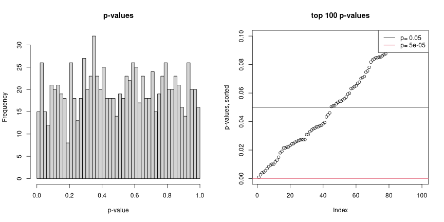

```r
tp <- replicate(1000, t.test(rnorm(20))$p.value)
layout(t(1:2))
hist(tp, breaks=40, xlab='p-value', main='p-values')
plot(sort(tp), xlim=c(1,100), ylim=c(0, 0.1), ylab='p-values, sorted', main='top 100 p-values')
abline(h=c(0.05, 0.05/length(tp)), col=1:2)
legend("topright", lty=1, col=1:2, legend=paste("p=", c(0.05, 0.05/length(tp))))
```

## False Discovery Rate

To tolerate *some* errors, control the *false discovery rate*.

Suppose you test 1,000 different songs to see if they make snails go faster, obtain a $p$-value for each song, set a threshold $p_0$, and study further those with $p < p_0$.

We expect* *no* false positives if $p_0 = 0.05 / 1000 = 0.00005$ (**Bonferroni**). ($*$*19 times out of 20*)

If $p_0$ is set to have a 5% *false discovery rate*,  
and 100 songs fall below the threshold,  
then we expect about 5 of these to be *false positives*.

[output not shown]

## Example: False Discovery Rate

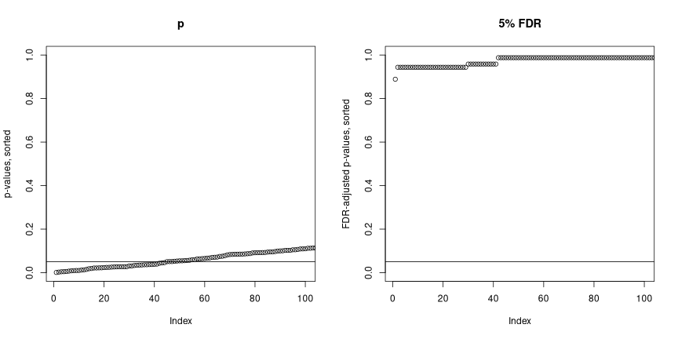

```r
layout(t(1:2))
plot(sort(tp), xlim=c(1,100), ylim=c(0, 1.0), ylab='p-values, sorted', main='p')
abline(h=0.05, col=1:2)
plot(sort(p.adjust(tp, method='fdr')), xlim=c(1,100), ylim=c(0, 1.0), ylab='FDR-adjusted p-values, sorted', main='5% FDR')
abline(h=0.05, col=1:2)
```

## Exercise:

Modify the code so that 20 of the datasets have a mean of $\mu=1$ (not zero, like below). See how many of the $p$-values are below 0.05

- with no correction
- with Bonerroni correction
- with an FDR correction

```
tp <- replicate(1000, t.test(rnorm(20))$p.value)
sprintf("%d of the %d p-values are below 0.05.", sum(tp < 0.05), length(tp))
layout(t(1:2))
hist(tp, breaks=40, xlab='p-value')
plot(sort(tp), xlim=c(1,100), ylim=c(0, 0.1), ylab='p-values, sorted')
abline(h=c(0.05, 0.05/length(tp)), col=1:2)
legend("topright", lty=1, col=1:2, legend=paste("p=", c(0.05, 0.05/length(tp))))
```

# Exercise

Design a simulation that tests the FDR correction:

- pick a framework and a statistical procedure making a $p$-value
- simulate a bunch of experiments
- some should have “real effect” and others not
- not all with a “real effect” should have high power
- how many true positives and false positives do you find with various $p$-value adjustments?

## In class

Plan:

We are studying whether there’s more crabs in tide pools at low vs high tide. So: within each tide pool we count numbers of crabs at low and high tide every day for a while.

- 300 tide pools
- count each pool once a day for 30 days
- do a t-test
- simulate from Poisson
- typically like 40 crabs per tide pool
- no difference between tides in 90% of the tide pools
- a difference in the remainder:
  - choose the diff randomly uniformly between 5 and 10, with more at high tide
- look at the percent of p-values that are < 0.05

```r
num_pools <- 300
num_obs <- 30
prob_diff <- 0.1
baseline <- 40

pools <- data.frame(
    id = 1:num_pools,
    is_different = rbinom(num_pools, size=1, prob=prob_diff)
) |> mutate(
    difference = ifelse(
        is_different,
        runif(num_pools, min=5, max=10),
        0
    ),
    mean_low_tide = baseline,
    mean_high_tide = baseline + difference
)
pools$avg_low_tide <- NA
pools$avg_high_tide <- NA
pools$t <- NA
pools$pval <- NA
for (k in 1:nrow(pools)) {
    low_nums <- rpois(num_obs, pools$mean_low_tide[k])
    high_nums <- rpois(num_obs, pools$mean_high_tide[k])
    pools$avg_low_tide[k] <- mean(low_nums)
    pools$avg_high_tide[k] <- mean(high_nums)
    tt <- t.test(low_nums, high_nums, paired=TRUE)
    pools$t[k] <- tt$statistic
    pools$pval[k] <- tt$p.value
}
```

What now?

1. sum all the pools that were significant
   - mean differences
   - is the difference zero
2. Adjust p-values with FDR,
   - plot with x=adjusted p-value, y=raw p-value
   - show where Bonferroni and FDR thresholds are
   - color by `is_different`

Let’s start with: How many pools have $p < 0.05$ that either do or do not have a difference (a) without correction; (b) with Bonferroni, (c) with FDR.

```r
pools |> mutate(
        is_different = ifelse(is_different, "different", "not diff"),
        bonferroni = p.adjust(pval, method="bonferroni"),
        fdr = p.adjust(pval, method="fdr")
 ) |>
    summarize(
        uncorrected=mean(pval < 0.05),
        bonferroni=mean(bonferroni < 0.05),
        fdr=mean(fdr < 0.05),
        n = n(),
        .by=is_different
)
```

```
##   is_different uncorrected bonferroni       fdr   n
## 1    different  0.88888889  0.4074074 0.7407407  27
## 2     not diff  0.05128205  0.0000000 0.0000000 273
```

Empirical FDR:

```r
adj_p <- p.adjust(pools$pval, method='fdr')
num_sig <- sum(adj_p < 0.05)
num_false_pos <- sum(adj_p < 0.05 & !pools$is_different)
fpr <- num_false_pos / num_sig
```

The empirical false positive rate is 0%.

# Many linear models

## Gene expression levels

From [*Host Genotype and Microbiota Contribute Asymmetrically to Transcriptional Variation in the Threespine Stickleback Gut* Clayton M. Small, Kathryn Milligan-Myhre, Susan Bassham, Karen Guillemin, William A. Cresko. Genome Biology and Evolution, March 2017.](https://academic.oup.com/gbe/article/9/3/504/3058199)

- Metadata: CVvsGF_RNAseq_Metadata.tsv ([direct link](https://github.com/uodsci/ds632/raw/main/datasets/stickleback_GFvsCV_RNAseq/CVvsGF_RNAseq_Metadata.tsv))
- RNA-Seq: CVvsGF_RNAseq_CPM.tsv ([direct link](https://github.com/uodsci/ds632/raw/main/datasets/stickleback_GFvsCV_RNAseq/CVvsGF_RNAseq_CPM.tsv))

## Study design:

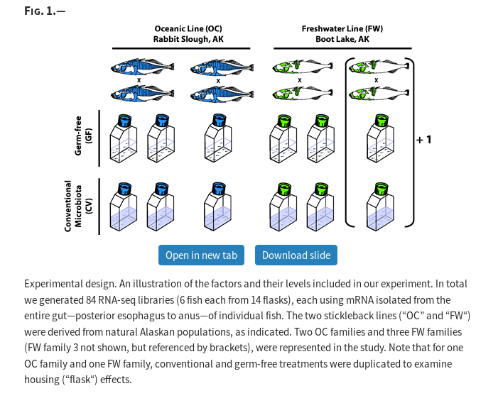

study_design

## The data

We’ll keep `expression` as a *matrix* (not a data frame) because it’s more convenient to do both row-wise and column-wise opertions.

```r
fish <- read.table("../datasets/stickleback_GFvsCV_RNAseq/CVvsGF_RNAseq_Metadata.tsv",
                   header=TRUE, sep='\t')
tmp <- read.table("../datasets/stickleback_GFvsCV_RNAseq/CVvsGF_RNAseq_CPM.tsv",
                  header=TRUE, sep='\t', stringsAsFactors=FALSE, check.names=FALSE)
genes <- tmp[,1:5]
expression <- as.matrix(tmp[,6:ncol(tmp)])
rownames(expression) <- genes$Gene_ID
# consistency check
stopifnot(all(match(colnames(expression), fish$Individual) == 1:nrow(fish)))
```

There are 8506 genes whose expression is measured in 84 fish.

## The fish

```r
fish
```

```
##    Individual Population Family Treatment Sex Flask
## 1       1A_02         FW    FW1        CV   M    1A
## 2       1A_03         FW    FW1        CV   F    1A
## 3       1A_04         FW    FW1        CV   F    1A
## 4       1A_05         FW    FW1        CV   M    1A
## 5       1A_08         FW    FW1        CV   F    1A
## 6       1A_10         FW    FW1        CV   M    1A
## 7       1D_01         FW    FW1        GF   F    1D
## 8       1D_02         FW    FW1        GF   M    1D
## 9       1D_04         FW    FW1        GF   M    1D
## 10      1D_06         FW    FW1        GF   F    1D
## 11      1D_07         FW    FW1        GF   M    1D
## 12      1D_08         FW    FW1        GF   F    1D
## 13      3A_01         FW    FW3        CV   F    3A
## 14      3A_02         FW    FW3        CV   M    3A
```

[output cut: 70 more lines]

## The plan

*Question:* which genes differ most in expression between treatment, while controlling for location (“population”). What about between sexes?

1. Normalize expression levels by gene so units are comparable.
2. For each gene, ask whether treatment and/or sex predict expression levels, controlling for population. *(anova)*
3. Find which genes have the strongest *evidence* and the strongest *effects*. *($p$-values)*
4. See whether it’s treatment or sex that’s creating those differences. *(coefficients)*

## Expression levels

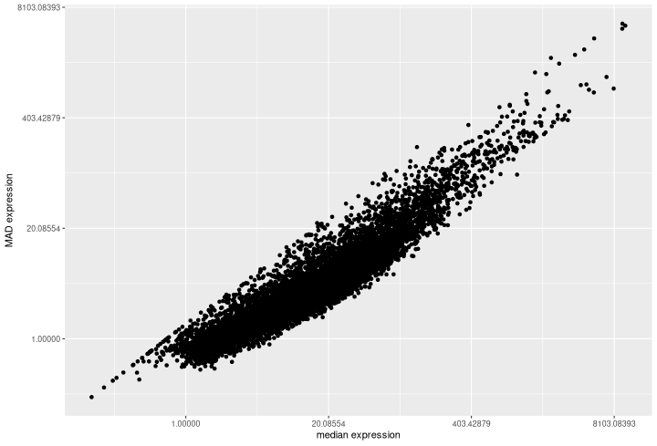

## Normalize

To put coefficients on the same scale, we’ll divide genes by their mean expression values.

```r
expr <- sweep(expression, 1, rowMeans(expression), "/")
```

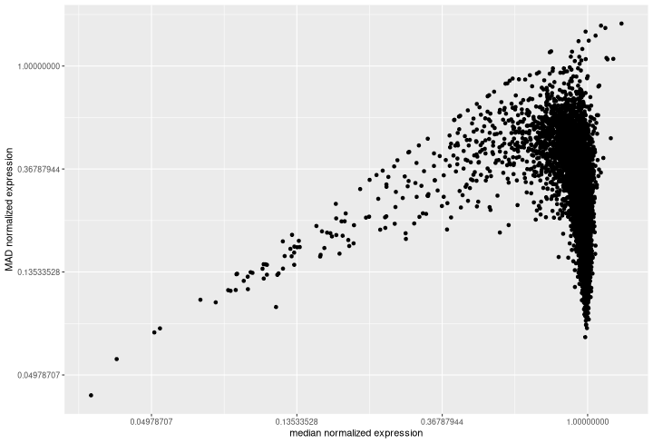

Fit *lots* of models: (*note:* could also be done [with purrr](https://purrr.tidyverse.org/articles/base.html))

```r
pop_lms <- apply(expr, 1, function (x) (lm(x ~ Population, data=fish)))
all_lms <- apply(expr, 1, function (x) (lm(x ~ Population + Treatment + Sex, data=fish)))
anovas <- mapply(anova, pop_lms, all_lms, SIMPLIFY=FALSE)
```

and extract coefficients, $p$-values

```r
pop_coefs <- sapply(pop_lms, coef)
all_coefs <- sapply(all_lms, coef)
pvals <- sapply(lapply(anovas, "[[", "Pr(>F)"), "[", 2)
```

## The $p$-values

… for an ANOVA comparing

```
    gene expression ~ Population
    gene expression ~ Population + Treatment + Sex
```

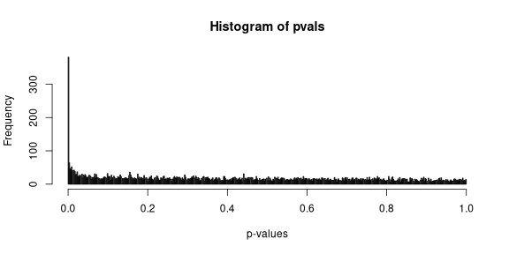

```r
hist(pvals, breaks=500, xlab='p-values')
```

1158 $p$-values are less than 0.05.

But, out of 8506, we’d *expect* about 425 to be less than 0.05.

Let’s look at the three *coefficients* for all the models:

```
    x ~ Population + Treatment + Sex
```

Coefficents, with $p < 0.05$ in red:

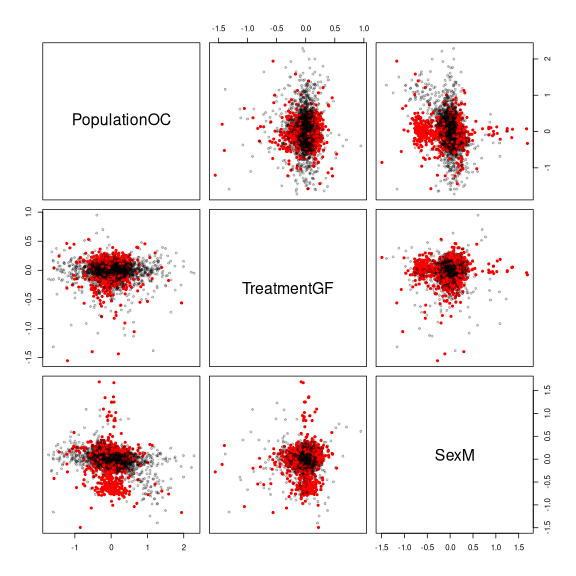

Coefficents, with $p < 0.05/n$ in red (*Bonferroni!*):

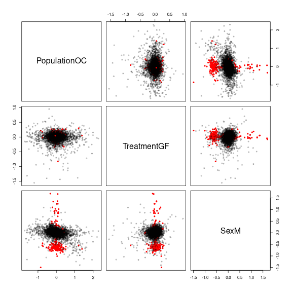

## The Bonferroni Bunch

```r
subset(genes, pvals < 0.05/nrow(genes))
```

```
##                 Gene_ID   Genome_Loc Gene_Start_bp                                                                                                                       Gene_Description
## 379  ENSGACG00000001729 scaffold_882          1249                                                                   *interleukin-8 [Lateolabrax japonicus];ABI48894 [Source:TopBlasxHit]
## 594  ENSGACG00000002048     groupXXI       2362051                                                       RNA-binding region (RNP1, RRM) containing 3 [Source:ZFIN;Acc:ZDB-GENE-060312-35]
## 833  ENSGACG00000002397       groupV        842100                                                                         stearoyl-CoA desaturase b [Source:ZFIN;Acc:ZDB-GENE-050522-12]
## 985  ENSGACG00000003874     groupXIX       5074262                                                                                    parvin, beta [Source:ZFIN;Acc:ZDB-GENE-030131-4411]
## 1005 ENSGACG00000003899     groupXIX       5087963                                                                                     parvin, gamma [Source:ZFIN;Acc:ZDB-GENE-070410-67]
## 1014 ENSGACG00000003911     groupXIX       5234537                                                                                         plexin b2b [Source:ZFIN;Acc:ZDB-GENE-080902-1]
## 1028 ENSGACG00000003928     groupXIX       5268421                                                        tubulin, gamma complex associated protein 6 [Source:HGNC Symbol;Acc:HGNC:18127]
## 1042 ENSGACG00000003947     groupXIX       5289965            adaptor protein, phosphotyrosine interaction, PH domain and leucine zipper containing 2 [Source:ZFIN;Acc:ZDB-GENE-081016-2]
## 1102 ENSGACG00000004020     groupXIX       5466205                                                                       transmembrane protein 117 [Source:ZFIN;Acc:ZDB-GENE-040426-2809]
## 1109 ENSGACG00000004028     groupXIX       5497683                                                                   twinfilin actin-binding protein 1 [Source:HGNC Symbol;Acc:HGNC:9620]
## 1128 ENSGACG00000004050     groupXIX       5505366                                                       interleukin-1 receptor-associated kinase 4 [Source:ZFIN;Acc:ZDB-GENE-040426-738]
## 1138 ENSGACG00000004063     groupXIX       5536933                                         ADAM metallopeptidase with thrombospondin type 1 motif, 20 [Source:HGNC Symbol;Acc:HGNC:17178]
## 1155 ENSGACG00000004088     groupXIX       5663914                                                                    prickle homolog 1a (Drosophila) [Source:ZFIN;Acc:ZDB-GENE-030724-5]
## 1161 ENSGACG00000004098     groupXIX       5670651                                                                                       periphilin 1 [Source:HGNC Symbol;Acc:HGNC:19369]
```

[output cut: 439 more lines]

## The paper

> We limited differential expression analysis to only those genes represented by at least two reads per million mapped (“copies per million,” CPM) in at least 12 of the 84 libraries (see supplementary fig. S1, Supplementary Material online). We normalized read counts for these 15,847 genes using TMM normalization (Robinson and Oshlack 2010) as implemented by the calcNormFactors function of the R/Bioconductor package edgeR (Robinson et al. 2010). In order to perform gene-wise differential expression analyses in a general linear model framework (Law et al. 2014), we supplied the TMM normalization factors to the voom function of the R/Bioconductor package limma (Ritchie et al. 2015), which generated appropriately weighted log2CPM expression values for all observations. We then fit a linear model for each gene including the fixed effects of factor levels for host population, host family (nested within host population), sex, and microbiota treatment using the limma lmFit function. We did not include a library “batch” effect in the model because initial nMDS ordination did not suggest batch as a major source of transcriptional variation, and our stratified assignment of samples to batches controlled for any confounding effect of batch with respect to other factors of interest. To account for variation between replicate flasks we incorporated flask as a random effect in the model using the limma duplicateCorrelation function. Each hypothesis of interest was tested, for each gene, using one or more contrasts via moderated t-tests applied by the limma function eBayes. To evaluate the effect of our microbiota treatment we performed a within-OC contrast, a within-FW contrast, and an overall contrast. Genes expressed differentially in any of these three contrasts were interpreted as being associated with the presence of microbes. We performed a single contrast to test for an overall effect of host population, and a single contrast to test for an interaction between host population and microbiota, both of these accounting for family differences nested within population. Finally, we performed contrasts to test for an effect of sex and a sex-by-microbiota interaction. For each of these seven contrasts, we controlled the false discovery rate (FDR) at 0.1 using the approach of Benjamini and Hochberg (1995), as implemented by the limma topTable function.

# Another look at error rates

Suppose that I got a positive result on an HIV test. What’s the chance I am HIV positive? (Here we *really* mean that “I” am a randomly chosen person from the US population.)

## Background data

OraQUICK advance rapid test: 99.4% specificity and 99.8% sensitivity (from [MLO online](https://www.mlo-online.com/the-changing-landscape-of-hiv-diagnostics.php)).

Refreshing from [Wikipedia](https://en.wikipedia.org/wiki/Sensitivity_and_specificity), specificity is the “true positive” rate and the sensitivity is the “true negative” rate:

- if you have HIV, the chance that it (wrongly) comes out negative is .006 = 0.6%;
- if you *don’t* have HIV, the chance that it (wrongly) comes out positive is .002 = 0.2%.

There are currently around [1.1 million people with HIV in the US](https://www.hiv.gov/hiv-basics/overview/data-and-trends/statistics), out of a total of [328 million](https://www.census.gov/popclock/), giving an overall rate of 0.00335 = 0.335%.

```r
true_pos <- .994
true_neg <- .998
pop_rate <- 1.1 / 328
```

## Probabilities

We want to know
$$\begin{aligned}
& \P\{ \text{HIV+} | \text{postive test} \} \\
& \qquad = \frac{\P\{ \text{HIV+ and getting a positive test}
\} }{ \P\{ \text{getting a positive test} \} }
\end{aligned}$$

## Making that concrete with simulation

Start with a large sample from the US population, some of whom have HIV and others do not, and then give them all HIV tests.

```r
N <- 1e6
people <- data.frame(
    hiv = runif(N) < pop_rate)
people$test <- NA
people$test[people$hiv] <- ifelse(runif(sum(people$hiv)) < true_pos, "+", "-")
people$test[!people$hiv] <- ifelse(runif(sum(!people$hiv)) < true_neg, "-", "+")
addmargins(table(status=people$hiv, test=people$test))
```

```
##        test
## status        -       +     Sum
##   FALSE  994744    2003  996747
##   TRUE       19    3234    3253
##   Sum    994763    5237 1000000
```

```r
addmargins(table(status=people$hiv, test=people$test))
```

```
##        test
## status        -       +     Sum
##   FALSE  994744    2003  996747
##   TRUE       19    3234    3253
##   Sum    994763    5237 1000000
```

For example, there are 2003 who do not have HIV but got a positive test result.

What is the **proportion of people who got a positive test result who actually have HIV**?

Now let’s compute: the probability we want is the **proportion of people who got a positive test result who actually have HIV**:

```r
hiv_given_plus <- sum(people$hiv & (people$test == "+")) / sum(people$test == "+")
```

The proportion of the 5237 in this sample of 10<sup>6</sup> that had a positive test result that *actually* have HIV is 3234/5237 = 61.75%.

## Conditional probabilities

We want to compute the theoretical probability of having HIV given a positive test result, or
$$P(\text{HIV} \;|\; + ) = \frac{P(\text{HIV and}\; +)}{P(+)}$$

The probability that a randomly chosen person from the population has HIV *and* got a positive test on this test is
$$\begin{aligned}
P(\text{HIV}\; \text{and}\; +) &=
P(\text{HIV}) \times P(+ \;|\; \text{HIV}) \\
&= 0.00335 \times 0.994 \\
&= 0.0033299
\end{aligned}$$

We’ll also need the complementary probability,
$$\begin{aligned}
P(\text{not HIV}\; \text{and}\; +) &=
P(\text{not HIV}) \times P(+ \;|\; \text{not HIV}) \\
&= (1 - 0.00335) \times (1 - 0.998) \\
&= 0.0019933
\end{aligned}$$

And, the probability that a randomly chosen person from the population has a positive test result is
$$\begin{aligned}
P(+)
&= P(\text{HIV and}\; +) + P(\text{not HIV and}\; +) \\
&= 0.0033299 + 0.0019933 \\
&= 0.0053232.
\end{aligned}$$

Putting these together, we get that
$$\begin{aligned}
P(\text{HIV} \;|\; + ) &= \frac{0.0033299}{0.0053232} \\
&= 0.6255448.
\end{aligned}$$
In other words, we get a predicted probability of 62.5%.